# Classification

Jeu de données res.PCA

.

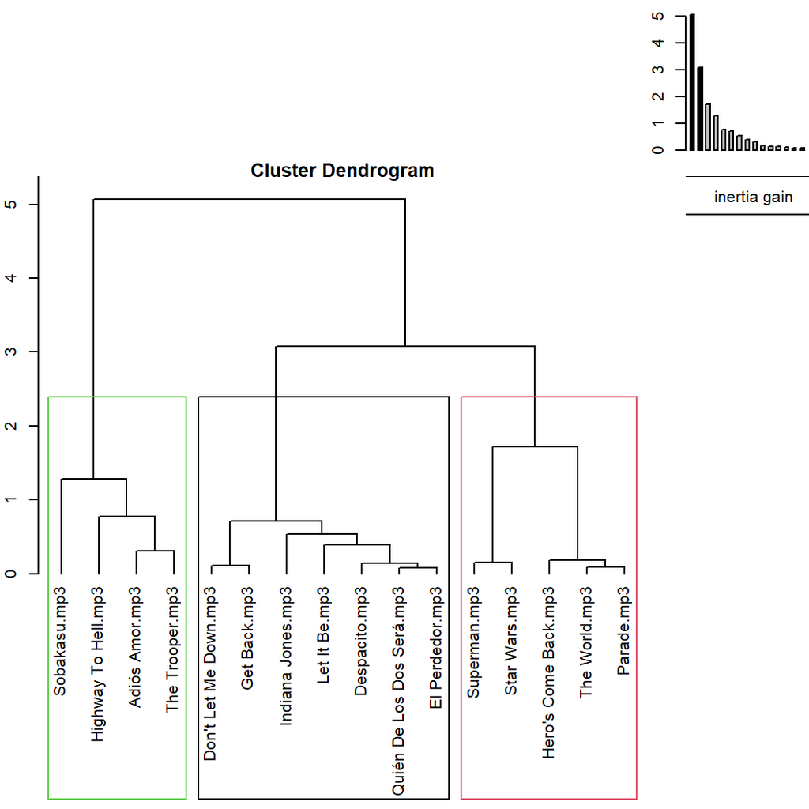

**Figure 1.1 - Arbre hiérarchique.**

La classification réalisée sur les individus fait apparaître 3 classes.

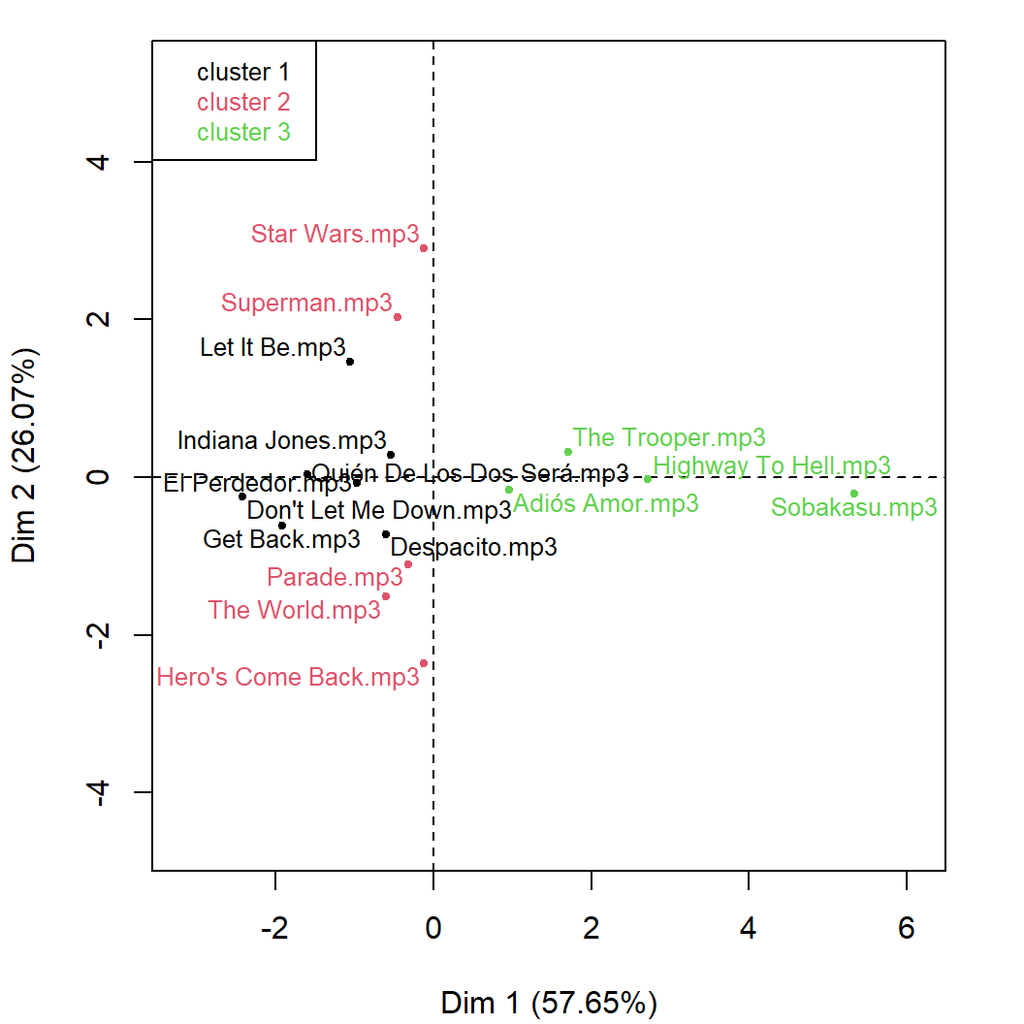

**Figure 1.2 - Classification Ascendante Hiérachique des individus.**

La **classe 1** est composée d’individus tels que *Don’t Let Me Down.mp3*, *Get Back.mp3* et *Let It Be.mp3*. Ce groupe est caractérisé par :

- de faibles valeurs pour les variables *LMean*, *LVar*, *LRan* et *LMed* (de la plus extrême à la moins extrême).

La **classe 2** est composée d’individus tels que *Star Wars.mp3*, *Superman.mp3*, *Hero’s Come Back.mp3* et *The World.mp3*. Ce groupe est caractérisé par :

- des variables dont les valeurs ne diffèrent pas significativement de la moyenne.

La **classe 3** est composée d’individus tels que *Sobakasu.mp3* et *Highway To Hell.mp3*. Ce groupe est caractérisé par :

- de fortes valeurs pour les variables *LRan*, *LMean*, *LMed* et *LVar* (de la plus extrême à la moins extrême).

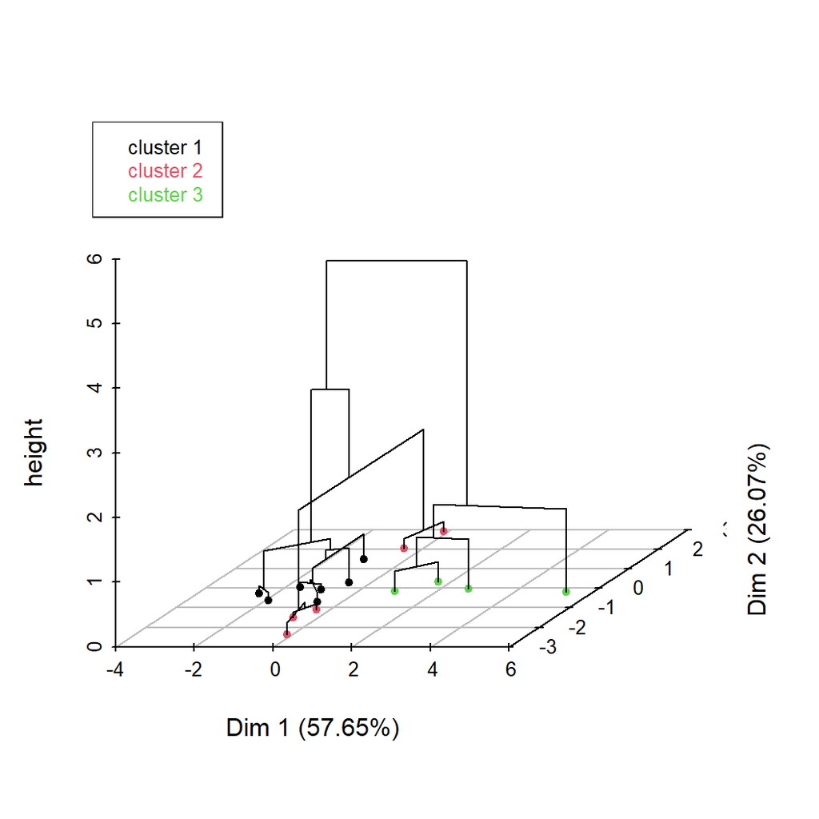

**Figure 1.3 - Arbre hiérarchique sur le plan factoriel.**

The hierarchical tree can be drawn on the factorial map with the individuals colored according to their clusters.